# Hierarchical Modelling

### Expectation-maximization

The challenge of mixture models is that at the start, we don’t know which observations belong to which cluster, nor what the parameters of each distribution is. It’s difficult to solve these problems at the same time- so an expectation-maximization (EM) algorithm takes the jump of estimating them one at a time, and **alternating** between them.

The first thing to do in an EM clustering algorithm is to assign our clusters **randomly**:

```r
set.seed(2016)
# We'll fit the clusters only with players that have had at least 20 at-bats
starting_data <- career %>%
  filter(AB >= 20) %>%
  select(-year, -bats, -isPitcher) %>%
  mutate(cluster = factor(sample(c("A", "B"), n(), replace = TRUE)))
```

#### Maximization

Now that we’ve got cluster assignments, what do the densities of each cluster look like?

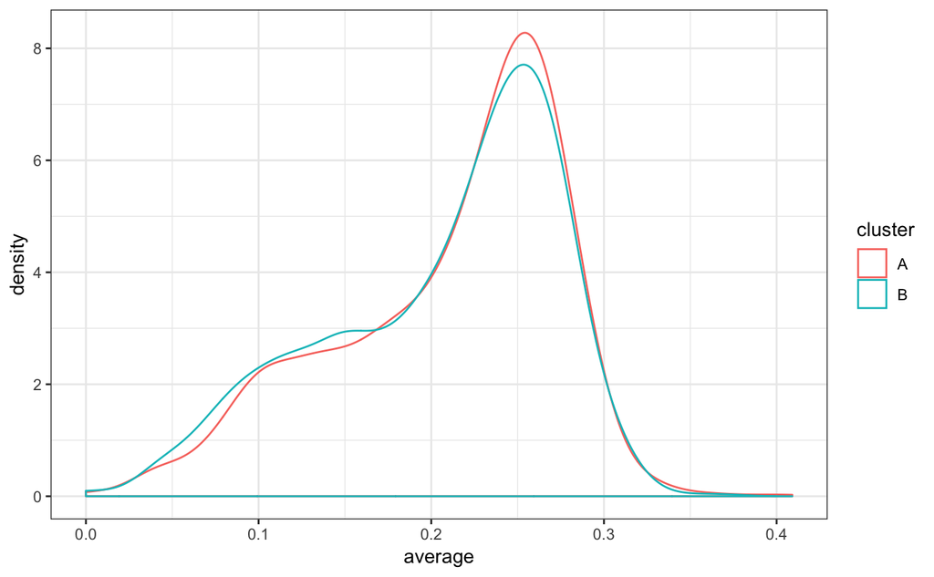

```r
starting_data %>%
  ggplot(aes(average, color = cluster)) +
  geom_density()
```

Well, that doesn’t look like much of a division- they have basically the same density! That’s OK: one of the nice features of expectation-maximization is that we don’t actually have to start with good clusters to end up with a good result.

We’ll now write a function for fitting a beta-binomial distribution using maximum likelihood estimation (and the `dbetabinom.ab` function from the VGAM package). This is a process we’ve done in multiple posts before, including the [appendix of one of the first ones](http://varianceexplained.org/r/empirical_bayes_baseball/). We’re just encapsulating it into a function.

```r
library(VGAM)
fit_bb_mle <- function(x, n) {
  # dbetabinom.ab is the likelihood function for a beta-binomial
  # using n, alpha and beta as parameters
  ll <- function(alpha, beta) {
    -sum(dbetabinom.ab(x, n, alpha, beta, log = TRUE))
  }
  m <- stats4::mle(ll, start = list(alpha = 3, beta = 10), method = "L-BFGS-B",
                   lower = c(0.001, .001))
  ab <- stats4::coef(m)
  data_frame(alpha = ab[1], beta = ab[2], number = length(x))
}
```

(The `number` column I added will be useful in the next step). For example, here are the alpha and beta chosen for the entire data as a whole:

```r
fit_bb_mle(starting_data$H, starting_data$AB)
```

```
# A tibble: 1 x 3
  alpha  beta number
  <dbl> <dbl>  <int>
1  12.7  45.1   3420
```

But now we’re working with a mixture model. This time, we’re going to fit the model within each of our (randomly assigned) clusters:

```r
fits <- starting_data %>%
  group_by(cluster) %>%
  do(fit_bb_mle(.$H, .$AB)) %>%
  ungroup()
fits
```

```
# A tibble: 2 x 4
  cluster alpha  beta number
  <fct>   <dbl> <dbl>  <int>
1 A        13.8  48.4   1651
2 B        11.8  42.4   1769
```

Another component of this model is the prior probability that a player is in cluster A or cluster B, which we set to 50-50 when we were assigning random clusters. We can estimate our new iteration of this based on the total number of assignments in each group, which is why we included the `number` column:

```r
fits <- fits %>%
  mutate(prior = number / sum(number))
fits
```

```
# A tibble: 2 x 5
  cluster alpha  beta number prior
  <fct>   <dbl> <dbl>  <int> <dbl>
1 A        13.8  48.4   1651 0.483
2 B        11.8  42.4   1769 0.517
```

Much as the within-cluster densities only changed a little, the priors only changed a little as well. This was the maximization step: find the maximum likelihood parameters (in this case, two alpha/beta values, and a per-cluster probability), pretending we knew the assignments.

### Expectation

We now have a distribution for each cluster. It’s worth noting that these are pretty similar distributions, and that neither is a good fit to the data.

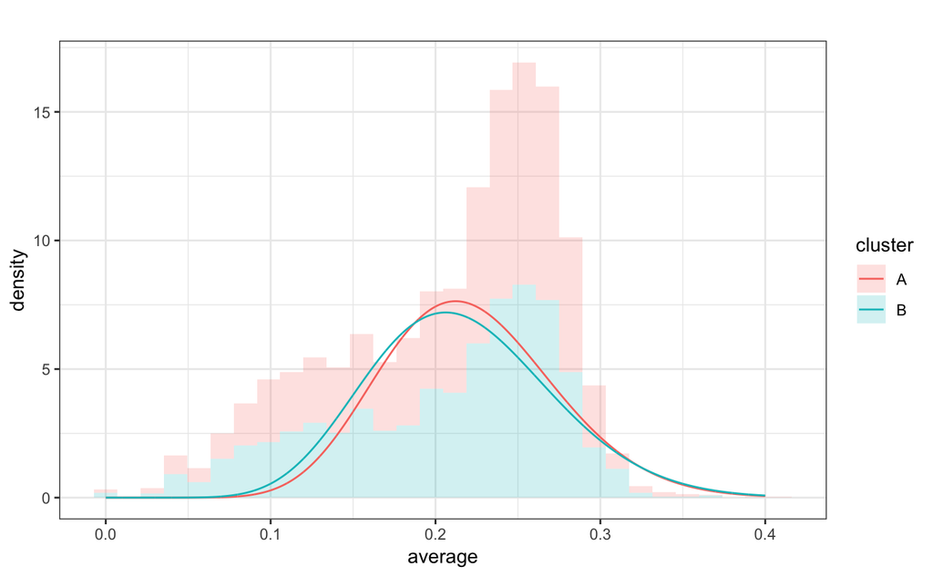

Consider therefore that each player has a likelihood it would have been generated from cluster A, and a likelihood it would have been generated from cluster B (being sure to weight each by the prior probability of being in A or B):

```r
crosses <- starting_data %>%
  select(-cluster) %>%
  crossing(fits) %>%
  mutate(likelihood = prior * VGAM::dbetabinom.ab(H, AB, alpha, beta))
crosses
```

```
# A tibble: 6,840 x 11
   playerID  name                   H    AB average cluster alpha  beta number prior likelihood
   <chr>     <chr>              <int> <int>   <dbl> <fct>   <dbl> <dbl>  <int> <dbl>      <dbl>
 1 abbotje01 Jeff Abbott           11    42  0.262  A        13.8  48.4   1651 0.483    0.0450
 2 abbotje01 Jeff Abbott           11    42  0.262  B        11.8  42.4   1769 0.517    0.0457
 3 abbotji01 Jim Abbott             2    21  0.0952 A        13.8  48.4   1651 0.483    0.0504
 4 abbotji01 Jim Abbott             2    21  0.0952 B        11.8  42.4   1769 0.517    0.0578
 5 abbotku01 Kurt Abbott          475  1860  0.255  A        13.8  48.4   1651 0.483    0.00145
 6 abbotku01 Kurt Abbott          475  1860  0.255  B        11.8  42.4   1769 0.517    0.00140
 7 abbotky01 Kyle Abbott            3    31  0.0968 A        13.8  48.4   1651 0.483    0.0306
 8 abbotky01 Kyle Abbott            3    31  0.0968 B        11.8  42.4   1769 0.517    0.0362
 9 abercre01 Reggie Abercrombie    86   386  0.223  A        13.8  48.4   1651 0.483    0.00869
10 abercre01 Reggie Abercrombie    86   386  0.223  B        11.8  42.4   1769 0.517    0.00868
# ... with 6,830 more rows
```

We can do that for every player using `group_by` and `top_n`:

```r
assignments <- starting_data %>%
  select(-cluster) %>%
  crossing(fits) %>%
  mutate(likelihood = prior * VGAM::dbetabinom.ab(H, AB, alpha, beta)) %>%
  group_by(playerID) %>%
  top_n(1, likelihood) %>%
  ungroup()
assignments
```

```
# A tibble: 3,420 x 11
   playerID  name                   H    AB average cluster alpha  beta number prior likelihood
   <chr>     <chr>              <int> <int>   <dbl> <fct>   <dbl> <dbl>  <int> <dbl>      <dbl>
 1 abbotje01 Jeff Abbott           11    42  0.262  B        11.8  42.4   1769 0.517   0.0457
 2 abbotji01 Jim Abbott             2    21  0.0952 B        11.8  42.4   1769 0.517   0.0578
 3 abbotku01 Kurt Abbott          475  1860  0.255  A        13.8  48.4   1651 0.483   0.00145
 4 abbotky01 Kyle Abbott            3    31  0.0968 B        11.8  42.4   1769 0.517   0.0362
 5 abercre01 Reggie Abercrombie    86   386  0.223  A        13.8  48.4   1651 0.483   0.00869
 6 abnersh01 Shawn Abner          110   531  0.207  B        11.8  42.4   1769 0.517   0.00668
 7 abreubo01 Bobby Abreu         1607  5395  0.298  B        11.8  42.4   1769 0.517   0.000225
 8 abreuto01 Tony Abreu           129   509  0.253  A        13.8  48.4   1651 0.483   0.00528
 9 acevejo01 Jose Acevedo           8   101  0.0792 B        11.8  42.4   1769 0.517   0.00313
10 aceveju01 Juan Acevedo           6    65  0.0923 B        11.8  42.4   1769 0.517   0.0110
# ... with 3,410 more rows
```

That’s the expectation step: **assigning each person to the most likely cluster**. How do our assignments look after that?

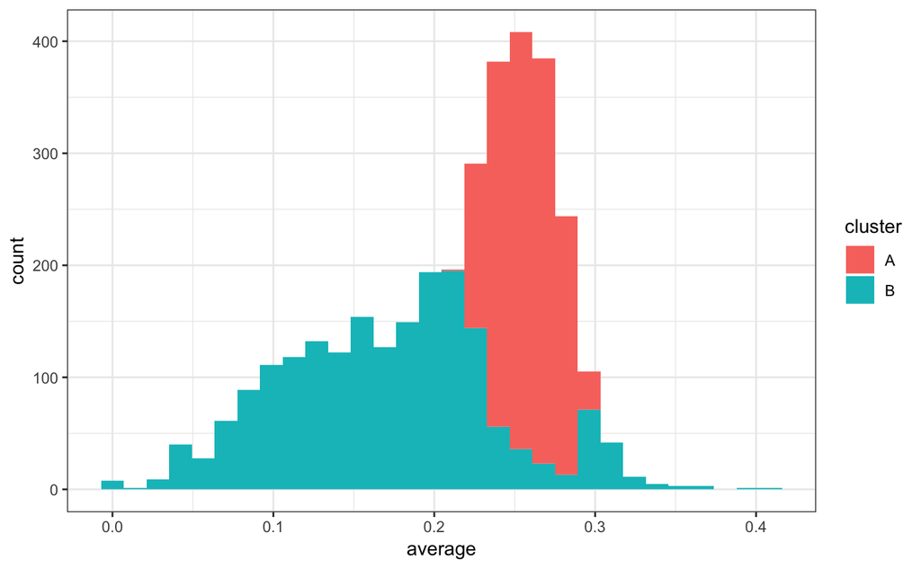

```r
ggplot(assignments, aes(average, fill = cluster)) +
  geom_histogram()
```

### Expectation-Maximization

The above two steps got to a better set of assignments than our original, random ones. But there’s no reason to believe these are as good as we can get. So we **repeat** the two steps, choosing new parameters for each distribution in the mixture and then making new assignments each time.

For example, now that we’ve reassigned each player’s cluster, we could re-fit the beta-binomial with the new assignments. Those distributions would look like this:

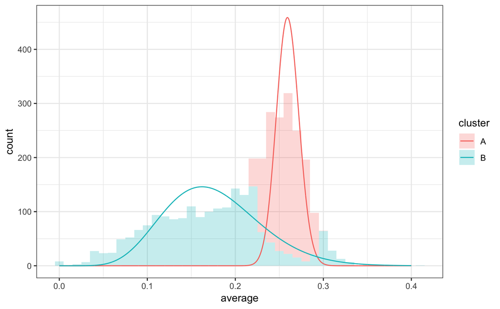

Unlike our first model fit, we can see that cluster A and cluster B have diverged a lot. Now we can take those parameters and perform a new estimation step. Generally we will do this multiple times, as an iterative process. This is the heart of an expectation-maximization algorithm, where we switch between assigning clusters (expectation) and fitting the model from those clusters (maximization).

```r
set.seed(1337)
iterate_em <- function(state, ...) {
  fits <- state$assignments %>%
    group_by(cluster) %>%
    do(mutate(fit_bb_mle(.$H, .$AB), number = nrow(.))) %>%
    ungroup() %>%
    mutate(prior = number / sum(number))
  assignments <- assignments %>%
    select(playerID:average) %>%
    crossing(fits) %>%
    mutate(likelihood = prior * VGAM::dbetabinom.ab(H, AB, alpha, beta)) %>%
    group_by(playerID) %>%
    top_n(1, likelihood) %>%
    ungroup()

  list(assignments = assignments,
       fits = fits)
}
library(purrr)
iterations <- accumulate(1:5, iterate_em, .init = list(assignments = starting_data))
```

Here I used the `accumulate` function from the `purrr` package, which is useful for running data through the same function repeatedly and keeping intermediate states. I haven’t seen others use this tidy approach to EM algorithms, and there are [existing R approaches to mixture models](http://ase.tufts.edu/gsc/gradresources/guidetomixedmodelsinr/mixed%20model%20guide.html?utm_source=dlvr.it&utm_medium=twitter).[^2] But I like this approach both because it’s transparent about what we’re doing in each iteration, and because our iterations are now combined in a tidy format, which is convenient to summarize and visualize.

For example, how did our assignments change over the course of the iteration?

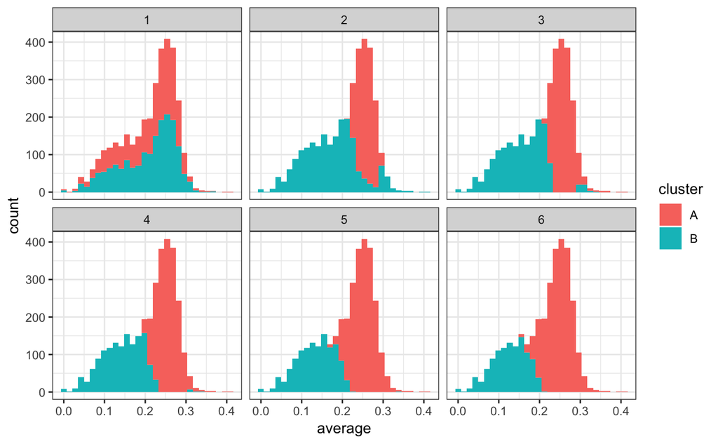

We notice that only the first few iterations led to a shift in the assignments, after which it appears to converge. Similarly, how did the estimated beta distributions change over these iterations?

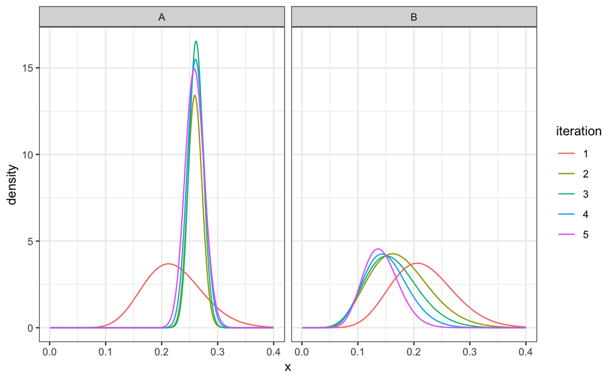

```r
fit_iterations <- iterations %>%
  map_df("fits", .id = "iteration")
fit_iterations %>%
  crossing(x = seq(.001, .4, .001)) %>%
  mutate(density = prior * dbeta(x, alpha, beta)) %>%
  ggplot(aes(x, density, color = iteration, group = iteration)) +
  geom_line() +
  facet_wrap(~ cluster)
```

### Assigning players to clusters

We now have some final parameters for each cluster:

```
# A tibble: 2 x 6
  iteration cluster alpha  beta number prior
  <chr>     <fct>   <dbl> <dbl>  <int> <dbl>
1 5         A       171     489   2184 0.639
2 5         B        16.8   101   1236 0.361
```

```r
batter_100 <- career %>%
  filter(AB == 100) %>%
  arrange(average)
batter_100
```

```
# A tibble: 5 x 8
  playerID  name            bats      H    AB  year average isPitcher
  <chr>     <chr>           <fct> <int> <int> <dbl>   <dbl> <lgl>
1 dejesjo01 Jose de Jesus   R        11   100  1990   0.110 T
2 mahonmi02 Mike Mahoney    R        18   100  2002   0.180 F
3 cancero01 Robinson Cancel R        20   100  2007   0.200 F
4 buschmi01 Mike Busch      R        22   100  1996   0.220 F
5 shealry01 Ryan Shealy     R        32   100  2006   0.320 F
```

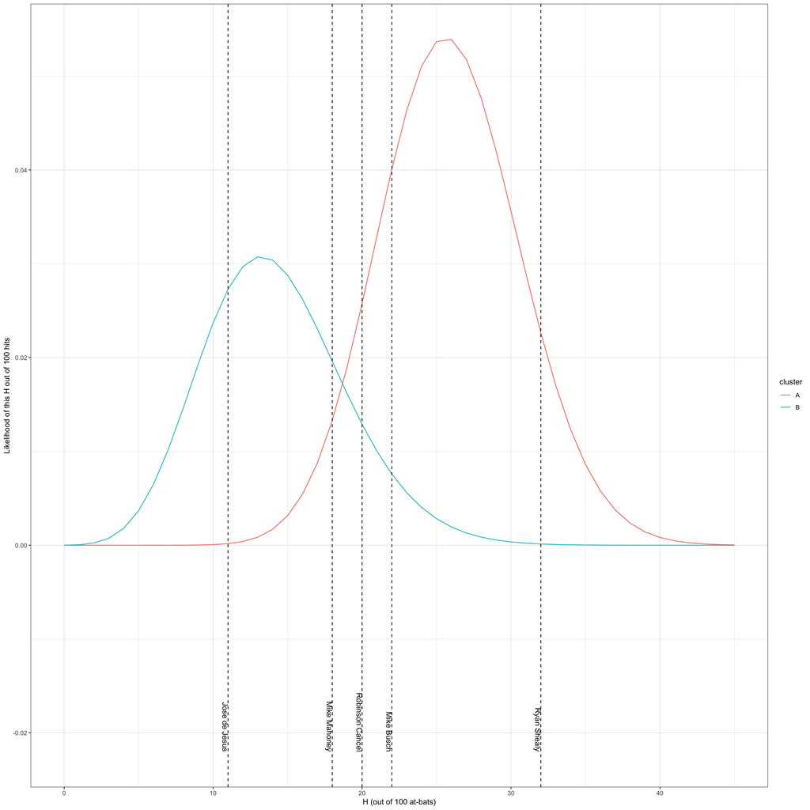

By Bayes’ Theorem, we can simply use the ratio of one likelihood (say, A in red) to the sum of the two likelihoods to get the posterior probability:

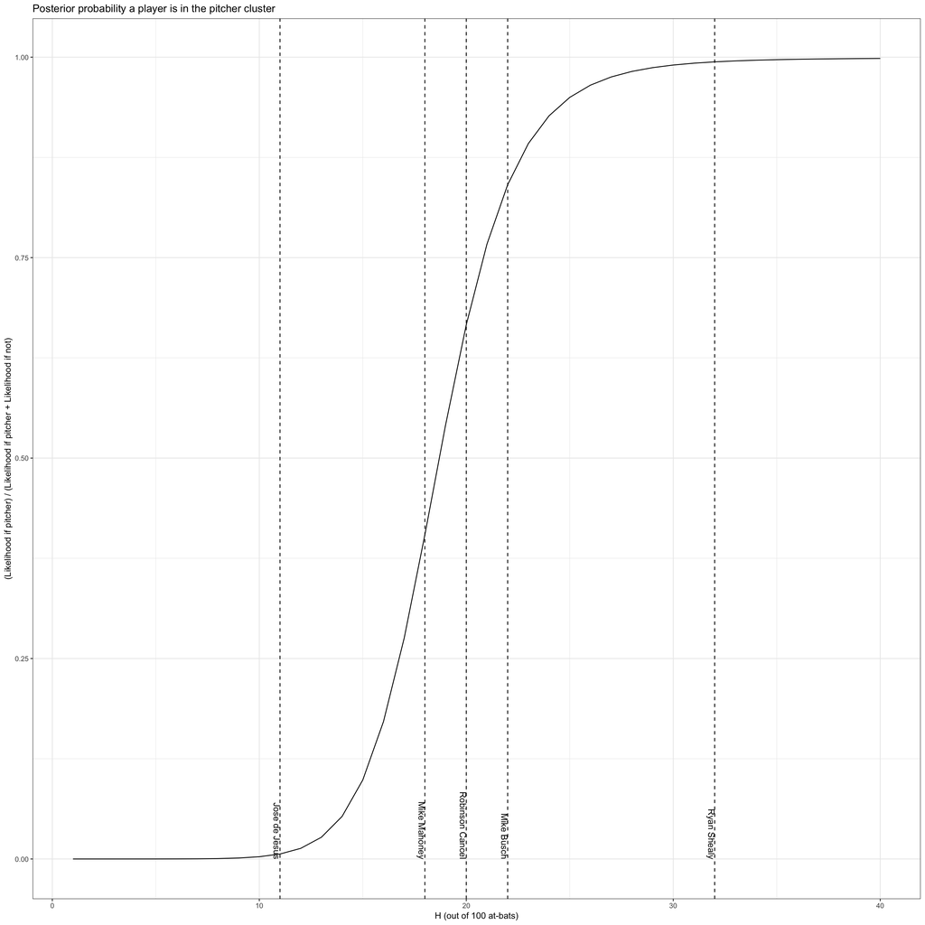

This allows us to assign all players in the dataset to one of the two clusters.

```r
career_likelihoods <- career %>%
  filter(AB > 20) %>%
  crossing(final_parameters) %>%
  mutate(likelihood = prior * VGAM::dbetabinom.ab(H, AB, alpha, beta)) %>%
  group_by(playerID) %>%
  mutate(posterior = likelihood / sum(likelihood))
career_assignments <- career_likelihoods %>%
  top_n(1, posterior) %>%
  ungroup()
```

```r
career_assignments %>%
  filter(posterior > .8) %>%
  count(isPitcher, cluster) %>%
  spread(cluster, n)
```

```
# A tibble: 2 x 3
  isPitcher     A     B
  <lgl>     <int> <int>
1 F          1843    71
2 T            68   686
```

Not bad, considering the only information we used was the batting average- and note that we didn’t even use data on who were pitchers to train the model, but just let the clusters define themselves.

### Empirical bayes shrinkage with a mixture model

We’ve gone to all this work posterior probabilities of each player’s assignments. How can we use this in [empirical Bayes shrinkage](http://varianceexplained.org/r/empirical_bayes_baseball/), or with the other methods we’ve described in this series?

Well, consider that all of our other methods have worked because the posterior was another beta distribution (thanks to the beta being the conjugate prior of the binomial). However, now that each point might belong to one of two beta distributions, our posterior will be a *mixture* of betas. This mixture is made up of the posterior from each cluster, weighted by the probability the point belongs to that cluster.

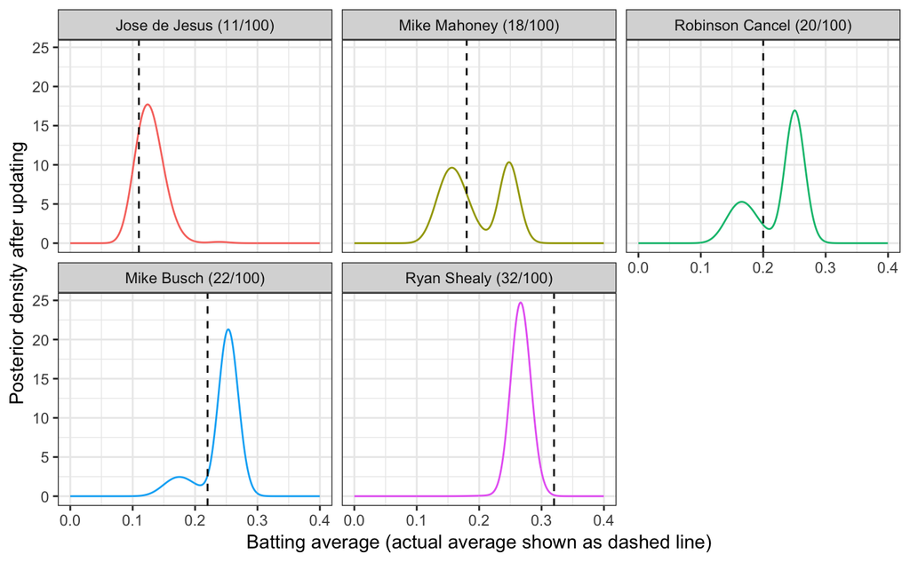

```r
batting_data <- career_likelihoods %>%
  ungroup() %>%
  filter(AB == 100) %>%
  mutate(name = paste0(name, " (", H, "/", AB, ")"),
         name = reorder(name, H),
         alpha1 = H + alpha,
         beta1 = AB - H + beta)
batting_data %>%
  crossing(x = seq(0, .4, .001)) %>%
  mutate(posterior_density = posterior * dbeta(x, alpha1, beta1)) %>%
  group_by(name, x) %>%
  summarize(posterior_density = sum(posterior_density)) %>%
  ggplot(aes(x, posterior_density, color = name)) +
  geom_line(show.legend = FALSE) +
  geom_vline(aes(xintercept = average), data = batting_data, lty = 2) +
  facet_wrap(~ name) +
  labs(x = "Batting average (actual average shown as dashed line)",
       y = "Posterior density after updating")
```

Can we perform shrinkage like we did in that early post? If our goal is still to find the mean of each posterior, then yes! Thanks to [linearity of expected value](https://en.wikipedia.org/wiki/Expected_value#Linearity), we can simply average the two distribution means, weighing each by the probability the player belongs to that cluster:

```r
eb_shrinkage <- career_likelihoods %>%
  mutate(shrunken_average = (H + alpha) / (AB + alpha + beta)) %>%
  group_by(playerID) %>%
  summarize(shrunken_average = sum(posterior * shrunken_average))
```

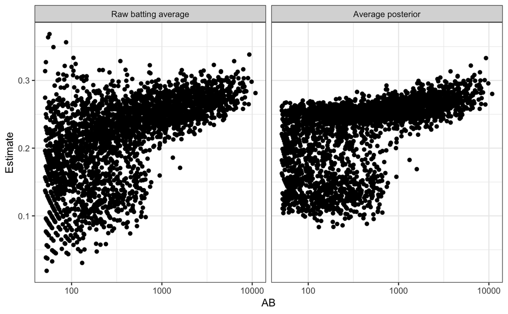

Notice that instead of shrinking towards a single value, the batting averages are now shrunken towards two centers: one higher value for the non-pitcher cluster, one smaller value for the pitcher cluster. Ones that are exactly in between don’t really get shrunken in either direction- they’re “pulled equally”.

(For simplicity’s sake I didn’t use our [beta-binomial regression](http://varianceexplained.org/r/beta_binomial_baseball/) approach in this model, but that could easily be added to take into account the relationship between average and AB).

Not all of the methods we’ve used in this series are so easy to adapt to a multimodal distribution. For example, a [credible interval](http://varianceexplained.org/r/credible_intervals_baseball/) is ambiguous in a multimodal distribution (see [here](https://en.wikipedia.org/wiki/Credible_interval) for more), and we’d need to rethink our approach to [Bayesian A/B testing](http://varianceexplained.org/r/bayesian_ab_baseball/). But since we do have a posterior distribution for each player- even though it’s not a beta- we’d be able to face these challenges.

### What’s Next: Combining into an R package

We’ve introduced a number of statistical techniques in this series for dealing with empirical Bayes, the beta-binomial relationship, A/B testing, etc. Since I’ve provided the code at each stage, you could certainly apply these methods to your own data (as [some already have!](http://juliasilge.com/blog/Bayesian-Blues/)). However, you’d probably find yourself copying and pasting a rather large amount of code, which isn’t necessarily something you want to do every time you run into this kind of binomial data (it takes you out of the flow of your own data analysis).

In my next post I’ll introduce an R package for performing empirical Bayes on binomial data that encapsulates many of the analyses we’ve performed in this series. These statistical techniques aren’t original to me (most can be found in an elementary Bayesian statistics textbook), but providing them in a convenient R package can still be useful for the community. We’ll also go over some of the choices one makes in developing a statistics package in R, particularly one that is compatible with the tidy tools we’ve been using.

[^1]: I’m changing this analysis slightly to look only at National League batters since the year 1980. Why? Because National League pitchers are required to bat (while American League pitchers don’t in typical games), and because looking at modern batters helps reduce the noise within each group.
[^2]: I should note that I haven’t yet gotten an existing R mixture model package to work with a beta-binomial model like we do in this post If you have an approach you’d recommend, please share it in the comments or on Twitter!